# Differential Gene Expression Analysis

Yuting Luo

2024-05-20

# Count normalization

## Normalization

### Install packages

#install DESeq2 package if (!require(“BiocManager”, quietly = TRUE)) install.packages(“BiocManager”)

BiocManager::install(“DESeq2”)

#install EdgeR package if (!require(“BiocManager”, quietly = TRUE)) install.packages(“BiocManager”)

BiocManager::install(“edgeR”)

### Read data files

```r
#set the working directory
setwd('E:/UH/FOR-271 Practical Bioinformatics/topic 8/RNA_seq_DEA')
```

### read raw data

```r
#read files
Coinfection.targets<-read.delim("./data/fileDesc.txt")

#change the rawnames of the dataframe Coinfection.targets
rownames(Coinfection.targets)<-c("Ha1","Ha2","Ha3","Ctr1","Ctr2","Ctr3")
```

```r
#load package
library(edgeR)
#read files
Coinfection.orig <- readDGE(Coinfection.targets, header=F)

#check the dimension of the data set
dim(Coinfection.orig)
```

```
## [1] 51751     6
```

```r
#chreck the first 6 rows of the data
head(Coinfection.orig)
```

```
## An object of class "DGEList"
## $samples
##           files.path inoculation         description           files group
## Ha1   ./data/Ha1.txt          Ha H.annosum infection  ./data/Ha1.txt     1
## Ha2   ./data/Ha2.txt          Ha H.annosum infection  ./data/Ha2.txt     1
## Ha3   ./data/Ha3.txt          Ha H.annosum infection  ./data/Ha3.txt     1
## Ctr1 ./data/Ctr1.txt         Ctr             Control ./data/Ctr1.txt     1
## Ctr2 ./data/Ctr2.txt         Ctr             Control ./data/Ctr2.txt     1
## Ctr3 ./data/Ctr3.txt         Ctr             Control ./data/Ctr3.txt     1
##      lib.size norm.factors
## Ha1  12510293            1
## Ha2   8033676            1
## Ha3  10094630            1
## Ctr1 10763763            1
## Ctr2 10539029            1
## Ctr3 12251172            1
##
## $counts
##             Samples
## Tags         Ha1 Ha2 Ha3 Ctr1 Ctr2 Ctr3
##   PITA_19277 274 169 195   90   80  329
##   PITA_36893   0   0   0    0    0    0
##   PITA_43071 157 101 150  128  133  127
##   PITA_31484   0   0   0    0    0    0
##   PITA_22913   0   0   0    0    0    0
##   PITA_43120  62  42  22   53   24   15
```

```r
#extract counts dataframe
Coinfection.rawCount <- Coinfection.orig$count
dim(Coinfection.rawCount)
```

```
## [1] 51751     6
```

```r
#check the data
head(Coinfection.rawCount)
```

```
##             Samples
## Tags         Ha1 Ha2 Ha3 Ctr1 Ctr2 Ctr3
##   PITA_19277 274 169 195   90   80  329
##   PITA_36893   0   0   0    0    0    0
##   PITA_43071 157 101 150  128  133  127
##   PITA_31484   0   0   0    0    0    0
##   PITA_22913   0   0   0    0    0    0
##   PITA_43120  62  42  22   53   24   15
```

### Build meta data

```r
#define sampletype: Control and Ha-infection
sampletype <- factor(c(rep("Ha",3), rep("Ctr", 3)))

#Build meta data frame
meta <- data.frame(sampletype, row.names = colnames(Coinfection.orig$count))

#check the column name of counts dataframe
colnames(Coinfection.orig$count)
```

```
## [1] "Ha1"  "Ha2"  "Ha3"  "Ctr1" "Ctr2" "Ctr3"
```

```r
#check the rowname of meta dataframe
rownames(meta)
```

```
## [1] "Ha1"  "Ha2"  "Ha3"  "Ctr1" "Ctr2" "Ctr3"
```

```r
#Check that sample names match in both files
all(colnames(Coinfection.orig$count) %in% rownames(meta))
```

```
## [1] TRUE
```

### Create DESeqDataset object

```r
#load the package
library(DESeq2)
dds <- DESeqDataSetFromMatrix(Coinfection.orig, colData = meta, design = ~ sampletype)
#view dds
head(counts(dds))
```

```
##             Samples
## Tags         Ha1 Ha2 Ha3 Ctr1 Ctr2 Ctr3
##   PITA_19277 274 169 195   90   80  329
##   PITA_36893   0   0   0    0    0    0
##   PITA_43071 157 101 150  128  133  127
##   PITA_31484   0   0   0    0    0    0
##   PITA_22913   0   0   0    0    0    0
##   PITA_43120  62  42  22   53   24   15
```

### Generate size factors

```r
#generate size factors
dds <- estimateSizeFactors(dds)
#view
sizeFactors(dds)
```

```
##       Ha1       Ha2       Ha3      Ctr1      Ctr2      Ctr3
## 1.1734464 0.7897579 0.9805609 1.0611942 0.9794690 1.1512821
```

### Generate the normalized counts

```r
normalized_counts <- counts(dds, normalized=TRUE)
write.csv(normalized_counts, file="./results/coinfection_normalized_counts_DESeq2.csv")
```

# Sample-level quality Control

## Principal Component Analysis (PCA)

### Using our dataset for PCA

```
## using ntop=500 top features by variance
```

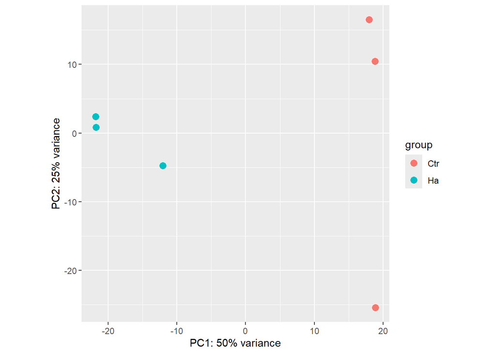

```r
#transform counts for data visualization
rld <- rlog(dds, blind=TRUE)

#plot PCA
plotPCA(rld, intgroup="sampletype")
```

```r
#save the plot
pdf("./results/PlotPCA_dds.pdf")
plotPCA(rld, intgroup="sampletype")
```

```
## using ntop=500 top features by variance
```

```r
dev.off()
```

### Exercise:

1.What does the above plot tell you about the similarity of samples? The blue dots labeled ‘Ha’ are clustered together on the left side of the plot. The red dots labeled ‘Ctr’ are located on the right side of the plot. The samples within each group are similar to each other but are significantly different from the the other group.The blue dots are more similar to each other than the red dots.

3.What do you think the %variance information (in the axes titles) tell you about the data in the context of the PCA? PC1: 50% variance - This indicates that the first principal component accounts for 50% of the total variation in the dataset. This high percentage suggests that the major differences between the samples are captured by PC1. It reflects a strong effect of the infection on the gene expression. And it is the major factor that separates the samples in the dataset. PC2: 25% variance - The second principal component accounts for 25% of the variance. This is also significant, indicating other variations in the dataset that are not captured by PC1 but are still relevant. It shows the secondary but important differences among the samples.

## Hierarchical Clustering Heatmap

```r
rld_mat <- assay(rld)
# compute the pairwise correlation values
rld_cor <- cor(rld_mat)

#check the output
head(rld_cor)
```

```
##            Ha1       Ha2       Ha3      Ctr1      Ctr2      Ctr3
## Ha1  1.0000000 0.9974935 0.9978500 0.9956639 0.9956698 0.9937710
## Ha2  0.9974935 1.0000000 0.9978706 0.9961065 0.9957914 0.9953450
## Ha3  0.9978500 0.9978706 1.0000000 0.9956039 0.9954369 0.9943809
## Ctr1 0.9956639 0.9961065 0.9956039 1.0000000 0.9967852 0.9946562
## Ctr2 0.9956698 0.9957914 0.9954369 0.9967852 1.0000000 0.9943313
## Ctr3 0.9937710 0.9953450 0.9943809 0.9946562 0.9943313 1.0000000
```

```r
#check the data
head(meta)
```

```
##      sampletype
## Ha1          Ha
## Ha2          Ha
## Ha3          Ha
## Ctr1        Ctr
## Ctr2        Ctr
## Ctr3        Ctr
```

```r
#Install pheatmap package and load the package
#install.packages("pheatmap")
#?pheatmap # help page for pheatmap
```

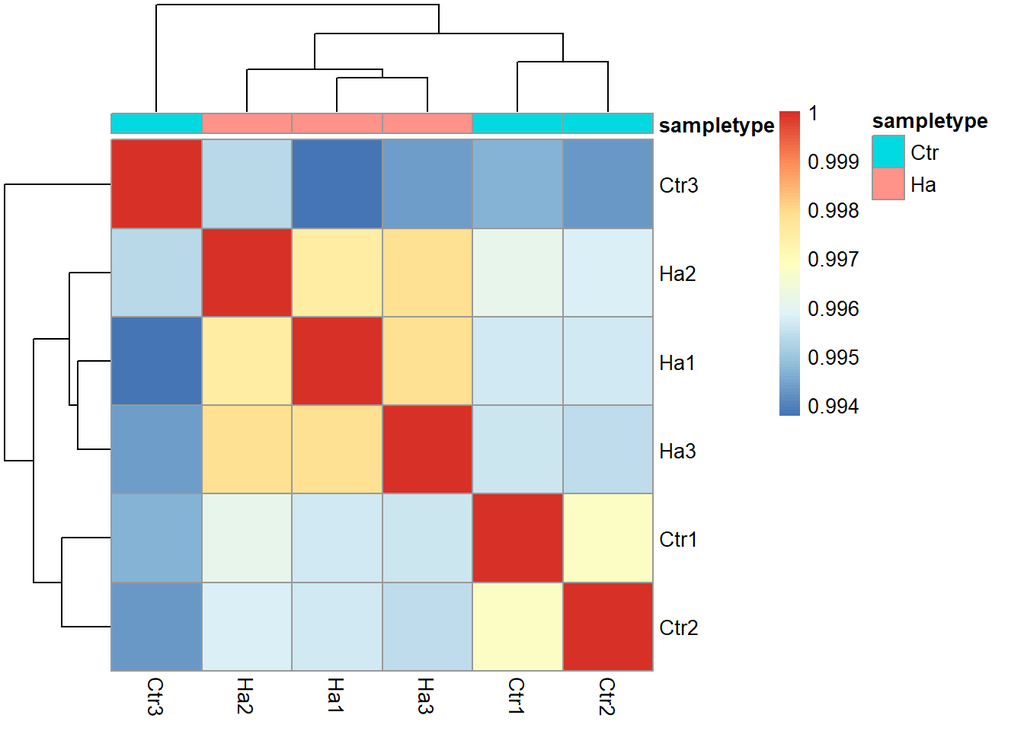

```r
#plot the heatmap
library(pheatmap)
pheatmap(rld_cor, annotation = meta)
```

```r
pdf("./results/PlotHeatmap_dds.pdf")
heat.colors <- RColorBrewer::brewer.pal(6, "Blues")
pheatmap(rld_cor, annotation = meta, color = heat.colors, border_color=NA, fontsize = 10,
        fontsize_row = 10, height=20)
```

# Differential expression analysis (DEA) using EdgeR

```r
#load EdgeR package
library(edgeR)
options(digits=3)
#read files
infection.targets<-read.delim("./data/fileDesc.txt")
#check Coinfection.targets
infection.targets
```

```
##        files.path inoculation         description
## 1  ./data/Ha1.txt          Ha H.annosum infection
## 2  ./data/Ha2.txt          Ha H.annosum infection
## 3  ./data/Ha3.txt          Ha H.annosum infection
## 4 ./data/Ctr1.txt         Ctr             Control
## 5 ./data/Ctr2.txt         Ctr             Control
## 6 ./data/Ctr3.txt         Ctr             Control
```

```r
#change the rawnames
rownames(infection.targets)<-c("Ha1","Ha2","Ha3","Ctr1","Ctr2","Ctr3")
#check the rawnames
infection.targets
```

```
##           files.path inoculation         description
## Ha1   ./data/Ha1.txt          Ha H.annosum infection
## Ha2   ./data/Ha2.txt          Ha H.annosum infection
## Ha3   ./data/Ha3.txt          Ha H.annosum infection
## Ctr1 ./data/Ctr1.txt         Ctr             Control
## Ctr2 ./data/Ctr2.txt         Ctr             Control
## Ctr3 ./data/Ctr3.txt         Ctr             Control
```

```r
#read and merges the files
infection <- readDGE(infection.targets, header=F)
#Check the dimension of DGElist R object
dim(infection)
```

```
## [1] 51751     6
```

```r
head(infection)
```

```
## An object of class "DGEList"
## $samples
##           files.path inoculation         description           files group
## Ha1   ./data/Ha1.txt          Ha H.annosum infection  ./data/Ha1.txt     1
## Ha2   ./data/Ha2.txt          Ha H.annosum infection  ./data/Ha2.txt     1
## Ha3   ./data/Ha3.txt          Ha H.annosum infection  ./data/Ha3.txt     1
## Ctr1 ./data/Ctr1.txt         Ctr             Control ./data/Ctr1.txt     1
## Ctr2 ./data/Ctr2.txt         Ctr             Control ./data/Ctr2.txt     1
## Ctr3 ./data/Ctr3.txt         Ctr             Control ./data/Ctr3.txt     1
##      lib.size norm.factors
## Ha1  12510293            1
## Ha2   8033676            1
## Ha3  10094630            1
## Ctr1 10763763            1
## Ctr2 10539029            1
## Ctr3 12251172            1
##
## $counts
##             Samples
## Tags         Ha1 Ha2 Ha3 Ctr1 Ctr2 Ctr3
##   PITA_19277 274 169 195   90   80  329
##   PITA_36893   0   0   0    0    0    0
##   PITA_43071 157 101 150  128  133  127
##   PITA_31484   0   0   0    0    0    0
##   PITA_22913   0   0   0    0    0    0
##   PITA_43120  62  42  22   53   24   15
```

```r
#Get the raw mapped count before filtering
infection.rawCount <- infection$count
head(infection.rawCount)
```

```
##             Samples
## Tags         Ha1 Ha2 Ha3 Ctr1 Ctr2 Ctr3
##   PITA_19277 274 169 195   90   80  329
##   PITA_36893   0   0   0    0    0    0
##   PITA_43071 157 101 150  128  133  127
##   PITA_31484   0   0   0    0    0    0
##   PITA_22913   0   0   0    0    0    0
##   PITA_43120  62  42  22   53   24   15
```

```r
library(ggplot2)
```

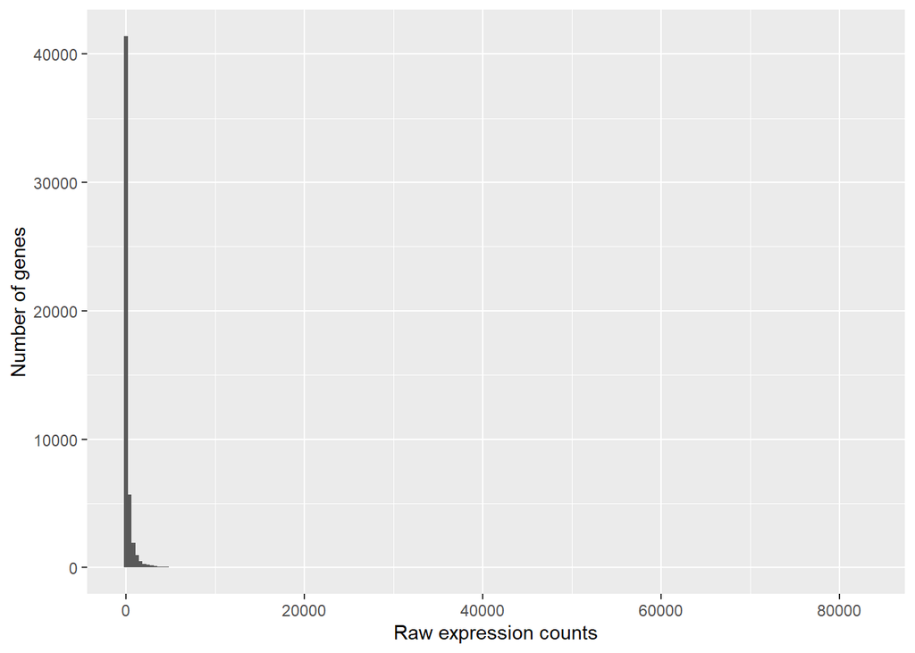

```r
#plot a histogram of the counts for a single sample, ‘Ha1’
ggplot(infection.rawCount) +
  geom_histogram(aes(x = Ha1), stat = "bin", bins = 200) +
  xlab("Raw expression counts") +
  ylab("Number of genes")
```

```r
#Export the .png file
png("./results/count distribution.png", res=300, height=1800, width=1800)
ggplot(infection.rawCount) +
  geom_histogram(aes(x = Ha1), stat = "bin", bins = 200) +
  xlab("Raw expression counts") +
  ylab("Number of genes")
dev.off()
```

```r
#Export raw count table into results folder
write.csv(infection.rawCount, file="./results/infection.rawCounts.csv")
#Get the counts per million (TMM normalised) before filtering
infection.normCPM <- cpm(calcNormFactors(infection))
dim(infection.normCPM)
```

```
## [1] 51751     6
```

```r
#Check the normalised counts
head(infection.normCPM)
```

```
##             Samples
## Tags           Ha1   Ha2   Ha3  Ctr1  Ctr2  Ctr3
##   PITA_19277 22.35 20.46 19.04  8.12  7.85 27.31
##   PITA_36893  0.00  0.00  0.00  0.00  0.00  0.00
##   PITA_43071 12.81 12.23 14.65 11.55 13.06 10.54
##   PITA_31484  0.00  0.00  0.00  0.00  0.00  0.00
##   PITA_22913  0.00  0.00  0.00  0.00  0.00  0.00
##   PITA_43120  5.06  5.09  2.15  4.78  2.36  1.24
```

```r
write.csv(infection.normCPM, file="./results/infection.normCPM.csv")
#Keep genes that are expressed at least 1 CPM in at least 3 libraries, normally it is the number of biological replicates of smaller group
infection.filtered <- rowSums(cpm(infection)>1) >=3
table(infection.filtered)
```

```
## infection.filtered
## FALSE  TRUE
## 25742 26009
```

```r
#Libraries size of data BEFORE filtering
infection$samples$lib.size
```

```
## [1] 12510293  8033676 10094630 10763763 10539029 12251172
```

```r
#cover the original file with our filter data
Infection <- infection[infection.filtered,]
#libraries size of data after filtering
colSums(Infection$counts)
```

```
##      Ha1      Ha2      Ha3     Ctr1     Ctr2     Ctr3
## 12455638  7998136 10047983 10717381 10497878 12206822
```

```r
dim(Infection)
```

```
## [1] 26009     6
```

```r
#Update the filtered libraries size
Infection$samples$lib.size <- colSums(Infection$counts)
Infection$samples
```

```
##           files.path inoculation         description           files group
## Ha1   ./data/Ha1.txt          Ha H.annosum infection  ./data/Ha1.txt     1
## Ha2   ./data/Ha2.txt          Ha H.annosum infection  ./data/Ha2.txt     1
## Ha3   ./data/Ha3.txt          Ha H.annosum infection  ./data/Ha3.txt     1
## Ctr1 ./data/Ctr1.txt         Ctr             Control ./data/Ctr1.txt     1
## Ctr2 ./data/Ctr2.txt         Ctr             Control ./data/Ctr2.txt     1
## Ctr3 ./data/Ctr3.txt         Ctr             Control ./data/Ctr3.txt     1
##      lib.size norm.factors
## Ha1  12455638            1
## Ha2   7998136            1
## Ha3  10047983            1
## Ctr1 10717381            1
## Ctr2 10497878            1
## Ctr3 12206822            1
```

```r
#Performed normalisation with TMM method
Infection = calcNormFactors(Infection)
#The libraries after normalisation
Infection$samples
```

```
##           files.path inoculation         description           files group
## Ha1   ./data/Ha1.txt          Ha H.annosum infection  ./data/Ha1.txt     1
## Ha2   ./data/Ha2.txt          Ha H.annosum infection  ./data/Ha2.txt     1
## Ha3   ./data/Ha3.txt          Ha H.annosum infection  ./data/Ha3.txt     1
## Ctr1 ./data/Ctr1.txt         Ctr             Control ./data/Ctr1.txt     1
## Ctr2 ./data/Ctr2.txt         Ctr             Control ./data/Ctr2.txt     1
## Ctr3 ./data/Ctr3.txt         Ctr             Control ./data/Ctr3.txt     1
##      lib.size norm.factors
## Ha1  12455638        0.981
## Ha2   7998136        1.021
## Ha3  10047983        1.011
## Ctr1 10717381        1.031
## Ctr2 10497878        0.969
## Ctr3 12206822        0.988
```

```r
#Get the counts per million (TMM normalised) after filtering
Infection.filtered.normCPM <-cpm(calcNormFactors(Infection))
#Export TMM normalized count table after filtering
write.csv(Infection.filtered.normCPM, file="./results/Infection.filtered.normCPM.csv")
```

## .differentailly gene expression analysis

```r
#Treatment factor
group<-factor(c('Ha','Ha','Ha',"Ctr","Ctr","Ctr"))
#Ctr is the intercept
Infection.design <- model.matrix(~group)
rownames(Infection.design)<-colnames(Infection$counts)
Infection.design
```

```
##      (Intercept) groupHa
## Ha1            1       1
## Ha2            1       1
## Ha3            1       1
## Ctr1           1       0
## Ctr2           1       0
## Ctr3           1       0
## attr(,"assign")
## [1] 0 1
## attr(,"contrasts")
## attr(,"contrasts")$group
## [1] "contr.treatment"
```

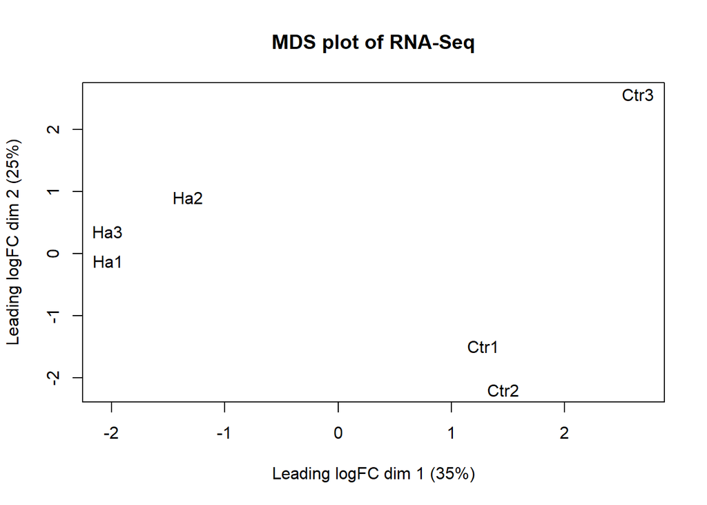

```r
#check outliers
plotMDS(Infection, main="MDS plot of RNA-Seq", labels=colnames(Infection$counts))
```

```r
#Export the MDS plot to a PNG file
png("./results/plotMDS.Infection.png", res=300, height=1800, width=1800)
plotMDS(Infection, main="MDS plot of Infection RNA-Seq", labels=colnames(Infection$counts))
dev.off()
```

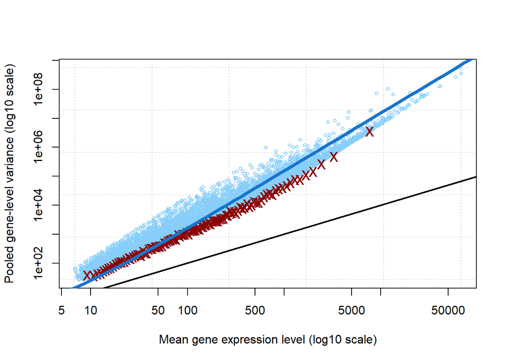

```r
#dispersion
Infection <- estimateGLMCommonDisp(Infection, Infection.design)
#Estimating the trended dispersion
Infection <- estimateGLMTrendedDisp(Infection, Infection.design)
#Estimating the tagwwise dispersion
Infection <- estimateGLMTagwiseDisp(Infection, Infection.design)
#visual representation of the mean-variance relationship and BCV-mean logCPM relationship
plotMeanVar(Infection, show.tagwise.vars=T,NBline=T)
```

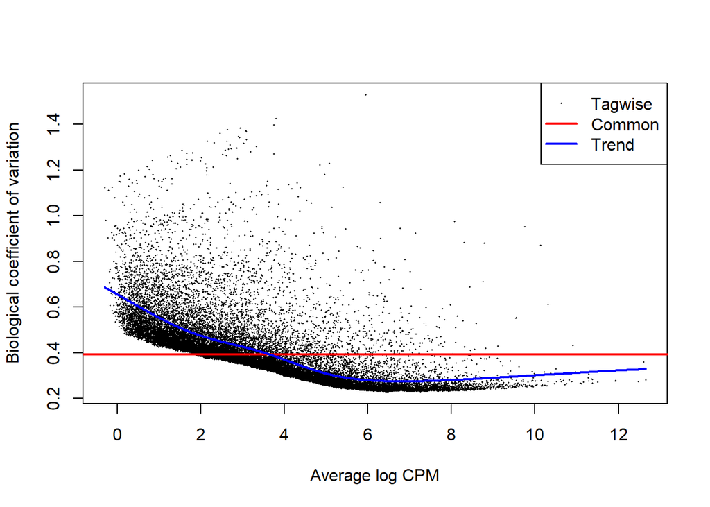

```r
plotBCV(Infection)
```

```r
#Fit DGEList and design matrix to genewise GLM
Infection.fit <- glmFit(Infection, Infection.design)
colnames(Infection.fit)
```

```
## [1] "(Intercept)" "groupHa"
```

```r
#Perform likelihood ratio test (LRT) to compare Ha vs Ctr
lrt.Ha_vs_Ctr <- glmLRT(Infection.fit, coef=2)
t1<-topTags(lrt.Ha_vs_Ctr, n=nrow(Infection))
head(t1$table)
```

```
##            logFC logCPM  LR   PValue      FDR
## PITA_45726  9.43   5.16 187 1.73e-42 4.49e-38
## PITA_40477 11.38   3.98 164 1.90e-37 2.47e-33
## PITA_34642 12.50   5.10 161 5.81e-37 5.04e-33
## PITA_21495  4.75   4.59 115 6.86e-27 4.46e-23
## PITA_07064  3.85   8.28 112 3.76e-26 1.96e-22
## PITA_20445  3.95   9.96 105 1.36e-24 5.89e-21
```

Total number of differentially expressed (DE) genes in different comparsion at FDR < 0.05

```r
summary(decideTests(lrt.Ha_vs_Ctr, adjust.method="BH", p.value=0.05))
```

```
##        groupHa
## Down       123
## NotSig   25423
## Up         463
```

```r
nrow(subset(topTags(lrt.Ha_vs_Ctr, n=586)$table,  logFC > 0))
```

```
## [1] 463
```

```r
lrt.Ha_vs_Ctr_UP <- subset(topTags(lrt.Ha_vs_Ctr, n=586)$table, logFC > 0)
#The DW-regulated genes (can change logFC to be more strict)
nrow(subset(topTags(lrt.Ha_vs_Ctr, n=586)$table,  logFC < 0))
```

```
## [1] 123
```

```r
lrt.Ha_vs_Ctr_DW <- subset(topTags(lrt.Ha_vs_Ctr, n=586)$table, logFC < 0)
```

Differentially expressed transcripts’ tag

```r
DEtags.lrt.Ha_vs_Ctr <- rownames(Infection)[as.logical(decideTests(lrt.Ha_vs_Ctr, adjust.method="BH", p.value=0.05))]
```

Export list of UP-regulated and DW-regulated transcripts

```r
write.csv(lrt.Ha_vs_Ctr_UP, file="./results/lrt.Ha_vs_Ctr_UP.csv")
write.csv(lrt.Ha_vs_Ctr_DW, file="./results/lrt.Ha_vs_Ctr_DW.csv")
```

To ask all the genes label as grey color

```r
Infection.colHavsCtr = rep('grey55', nrow(Infection))
```

To assign colour for DE transcripts

```r
Infection.colHavsCtr[lrt.Ha_vs_Ctr$table$PValue < 0.05 & lrt.Ha_vs_Ctr$table$logFC >0 ] <- "red"
Infection.colHavsCtr[lrt.Ha_vs_Ctr$table$PValue < 0.05 & lrt.Ha_vs_Ctr$table$logFC <0 ] <- "blue"
```

Plot Smear plot with adjustment on Y-axis label

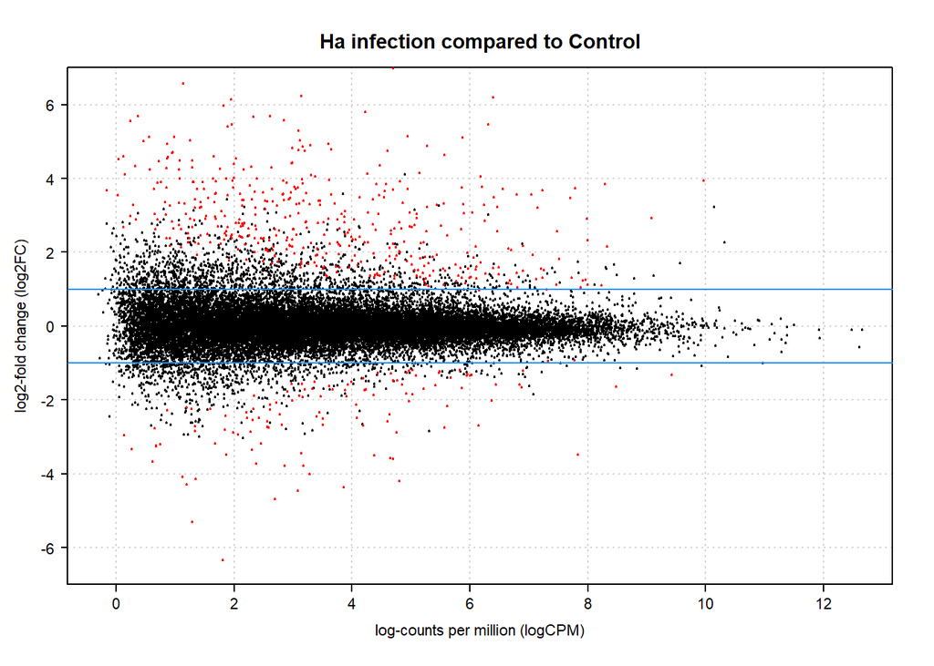

```r
par(omi=c(0.1,0.1,0.1,0.1), las=1, cex=0.5, mgp=c(3,1,0), cex.main=1.8, cex.lab=1.4, cex.axis=1.4)
plotSmear(lrt.Ha_vs_Ctr, de.tags=DEtags.lrt.Ha_vs_Ctr, xlab="log-counts per million (logCPM)", ylab="log2-fold change (log2FC)", main="Ha infection compared to Control", pch=19, cex=0.4, smearWidth=0.5, panel.first=grid(), smooth.scatter=FALSE, ylim=c(-7,7), yaxs="i")
abline(h=c(-1,1),col="dodgerblue")
```

Plot Smear plot with adjustment on Y-axis label and colour of DE tags changed

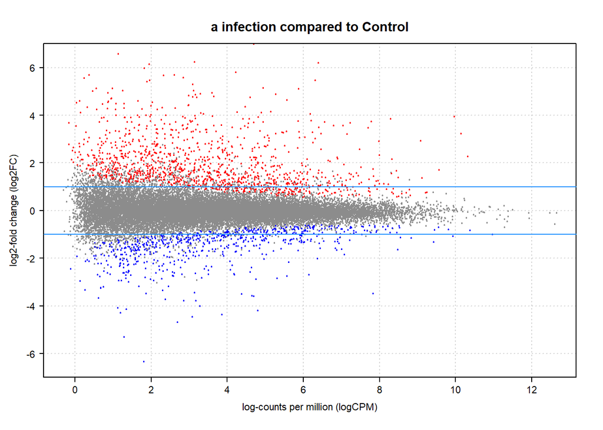

```r
par(omi=c(0.1,0.1,0.1,0.1), las=1, cex=0.5, mgp=c(3,1,0), cex.main=1.8, cex.lab=1.4, cex.axis=1.4)
plotSmear(lrt.Ha_vs_Ctr, xlab="log-counts per million (logCPM)", ylab="log2-fold change (log2FC)", main="a infection compared to Control", smearWidth=0.5, pch=21, cex=0.4, deCol="red", col=Infection.colHavsCtr, ylim=c(-7,7), yaxs="i")
abline(h=c(-1,1),col="dodgerblue")
```

Plot Smear plot with adjustment on Y-axis label and colour of DE tags changed and export as png

```r
png("./results/plotSmear.InfectionRNAseq.png", res=300, height=1800, width=1800)
par(omi=c(0.1,0.1,0.1,0.1), las=1, cex=0.5, mgp=c(3,1,0), cex.main=1.8, cex.lab=1.4, cex.axis=1.4)
plotSmear(lrt.Ha_vs_Ctr, xlab="log-counts per million (logCPM)", ylab="log2-fold change (log2FC)", main="Ha infection compared to Control", smearWidth=0.5, pch=21, cex=0.4, deCol="red", col=Infection.colHavsCtr, ylim=c(-7,7), yaxs="i")
abline(h=c(-1,1),col="dodgerblue")
dev.off()
```